# Introduction

Pourquoi les statistiques?

27 août 2018

## Quels types de questions font appel aux statistiques?

## Importance des statistiques

- Systèmes complexes
  - Plusieurs types d’entités / individus qui interagissent
  - Chaînes de cause à effet, rétroaction, etc.
- Variation entre individus
- Observations incomplètes
  - Nombre limité de variables
  - Nombre limité d’individus (échantillonnage)
  - Erreurs d’observation

# Méthode scientifique

## Méthode scientifique

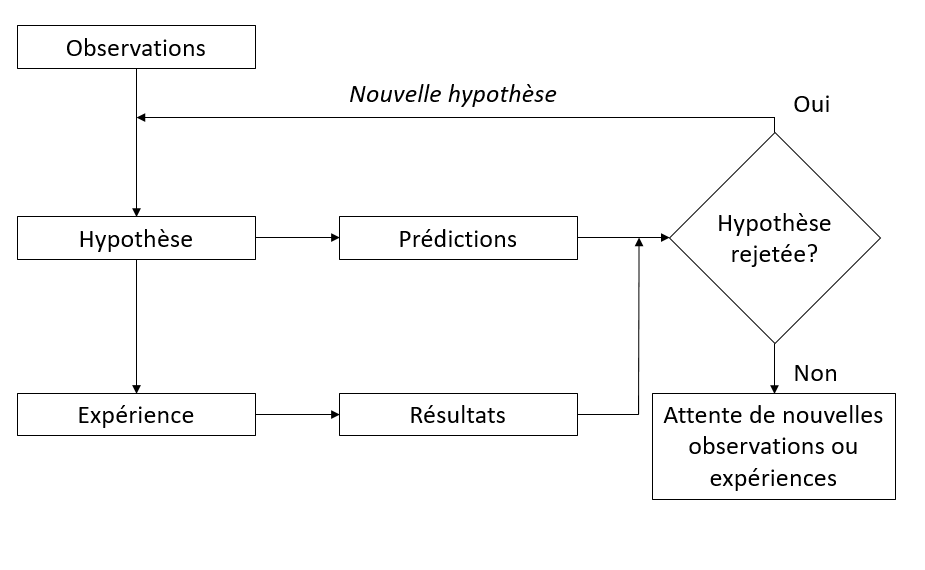

## Méthode scientifique

En pratique…

- Chaque étude scientifique ne contient pas toutes les étapes des la méthode scientifique classique.
- Toutes les questions scientifiques ne sont pas des tests d’hypothèse, par exemple:
  - Combien y a-t-il d’espèces d’oiseaux uniques à cette région?
  - Quelle est l’aire de répartition du pin gris? Comment sera-t-elle modifiée par les changements climatiques au 21e siècle?

# Rôles des statistiques

## Rôles des statistiques

- *Décrire* les caractéristiques sommaires d’un ensemble de données.
- À partir de mesures prises sur un échantillon d’individus, *estimer* les caractéristiques d’une variable, ou d’une relation entre variables, au niveau de la population.
- *Tester* une hypothèse portant sur ces variables ou relations entre variables.
- *Prédire* la valeur d’une variable pour un nouvel individu hors de l’échantillon.

## Rôles des statistiques

### Exemples

- Quel est le diamètre moyen des arbres mesurés dans une parcelle?
- Combien y a-t-il d’orignaux dans le Parc de la Vérendrye?
  - La population est-elle en croissance par rapport à l’année précédente?
  - Quelle sera la population dans 10 ans?

## Rôles des statistiques

Les trois dernières tâches (estimation, test d’hypothèse et prédiction) demandent de généraliser les connaissances acquises à partir d’un nombre limité d’observations.

Cela requiert un *modèle* du système étudié.

# Qu’est-ce qu’un modèle?

## Carte routière

[figure not shown]

## Structure d’une protéine

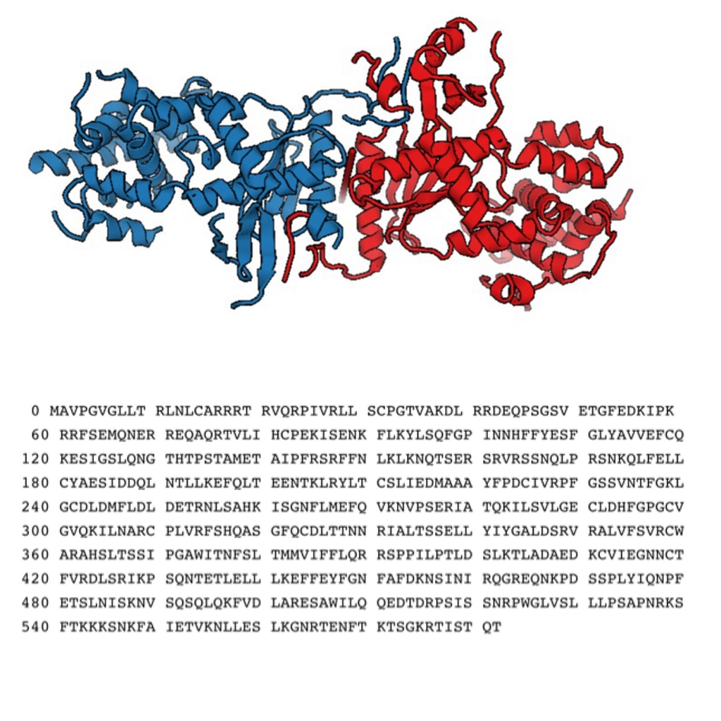

## Modèle prédateur-proie de Lotka-Volterra

$$x_{t+1} = a x_t - b x_t y_t$$
$$y_{t+1} = -c y_t + d x_t y_t$$

## Qu’est-ce qu’un modèle?

- Une représentation abstraite, simplifiée d’un système.
  - Tous les modèles sont inexacts.
  - On recherche souvent le modèle le plus simple qui retient les caractéristiques essentielles du système pour un problème donné (parcimonie).
- Inclut souvent des relations mathématiques entre les attributs observables (*variables*) des entités étudiées.
- Modèle statistique: associe les variables à une *distribution* représentant la probabilité de différentes valeurs possibles.

# Contenu du cours

## Contenu du cours

- Aujourd’hui: Statistiques descriptives et visualisations graphiques
- Semaine prochaine: Modèles statistiques, estimation de paramètres

## Contenu du cours

- Reste du cours en trois parties:
  - Introduction aux tests d’hypothèses, dans le contexte de la comparaison des effets de deux ou plusieurs traitements. (4 semaines)
  - Modèles de régression: expliquer la variation d’une variable réponse à partir de prédicteurs numériques ou catégoriques. (6 semaines)
  - Analyses multivariées: lorsque la réponse à expliquer est composée de plusieurs variables. (2 semaines)